# Academic Workshop Analysis: Ventilation Network Optimization

## 1. Introduction & Methodology

This report evaluates the spatial optimization performance of **15 architectural students** across **14 unique apartment layouts**. The study focuses on the fundamental trade-off in building system design: **Network Complexity** (turns) vs. **Spatial Efficiency** (path length).

### 1.1 Workshop Structure

The workshop progressed through three phases of increasing complexity:

- **Phase 1 (Floor 3):** Initial layouts for baseline logic.
- **Phase 2 (Floor 16):** Elongated plans requiring strategic routing.
- **Phase 3 (Floor 20):** High-constraint environments testing internalized logic.

## 2. Global Performance Distribution

We begin by standardizing the data (converting mm to $10^3$ mm) and visualizing the 'Design Footprint' of every student across all apartments. This helps identify general clusters and outliers in design strategy.

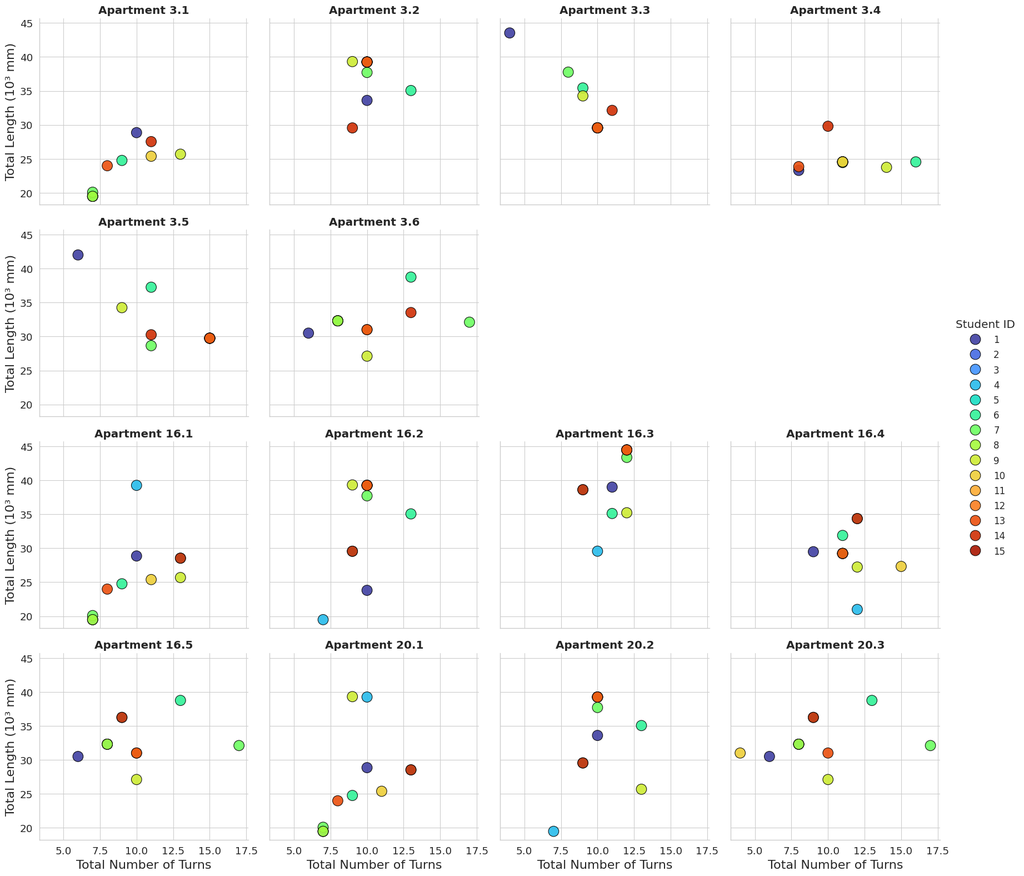

### Understanding the Global Distribution

In the chart above, we observe the 'Spatial Footprint' of each student.

- **Horizontal spread** represents design complexity (more turns).
- **Vertical spread** represents spatial efficiency (longer paths).

Notice how some apartments (like 3.2) show tight clusters, while others (like 20.1) show significant dispersion, reflecting the inherent difficulty of the layout.

### Plot Explanation

- **Facets:** Each box represents one Apartment, making it easy to see how different students solved the same spatial problem.
- **Colors:** Each dot is a Student. If you see clusters of different colors, it shows that students arrived at different design solutions (Turns vs. Length trade-offs).

## 3. Statistical Benchmarking & Metrics

To objectively evaluate performance, we apply three primary metrics:

1. **Efficiency Score (Z-Score):** Standardizes performance across different layout sizes ($Z = \frac{x - \mu}{\sigma}$).
2. **Pearson Correlation ($r$):** Determines if complexity (turns) successfully optimized length ($r < 0$) or caused a 'Complexity Trap' ($r > 0$).
3. **Coefficient of Variation (CoV):** Measures 'Design Divergence' to identify which layouts were 'solved' vs. 'creative puzzles'.

| Apartment | Avg Turns | Turns StdDev | Avg Length (10³ mm) | Length StdDev |
| --- | --- | --- | --- | --- |
| 3.1 | 8.67 | 2.10 | 22.81 | 3.59 |
| 3.2 | 10.08 | 1.00 | 37.50 | 3.15 |
| 3.3 | 9.25 | 1.82 | 32.51 | 4.49 |
| 3.4 | 11.08 | 2.19 | 24.75 | 1.65 |
| 3.5 | 12.75 | 3.08 | 31.73 | 4.06 |
| 3.6 | 9.92 | 3.06 | 32.14 | 2.63 |
| 16.1 | 9.58 | 2.47 | 25.30 | 5.71 |
| 16.2 | 9.75 | 1.36 | 34.23 | 6.97 |
| 16.3 | 11.17 | 1.19 | 40.16 | 4.97 |
| 16.4 | 11.50 | 1.38 | 29.32 | 3.51 |
| 16.5 | 9.67 | 2.87 | 32.69 | 3.08 |
| 20.1 | 9.25 | 2.22 | 26.43 | 7.01 |
| 20.2 | 10.08 | 1.62 | 33.91 | 6.55 |
| 20.3 | 9.17 | 3.30 | 32.69 | 3.08 |

### 3.1 Key Architectural Inferences

- **Complexity Peak (Apt 3.5):** Required the highest average turns (12.75), indicating significant spatial obstacles.
- **The Standardized Solution (Apt 3.2):** Lowest variability (StdDev 1.0), suggesting an obvious optimal path.
- **The Complexity Trap (Apt 3.1):** High positive correlation ($r=0.84$); adding turns significantly decreased efficiency here.

### Efficiency Analysis: Correlation & Ranking

We want to see if more turns (design effort) resulted in shorter paths (efficiency). A negative correlation suggests that adding turns helped students optimize length, while a positive correlation might suggest that some students simply struggled to find a direct path.

**Pearson Correlation ($r$):** Measures the linear relationship between Turns and Length. $$r = \frac{\sum(x_i - \bar{x})(y_i - \bar{y})}{\sqrt{\sum(x_i - \bar{x})^2 \sum(y_i - \bar{y})^2}}$$

- $r > 0$: Complexity increases length.
- $r < 0$: Strategic turns helped shorten the path.

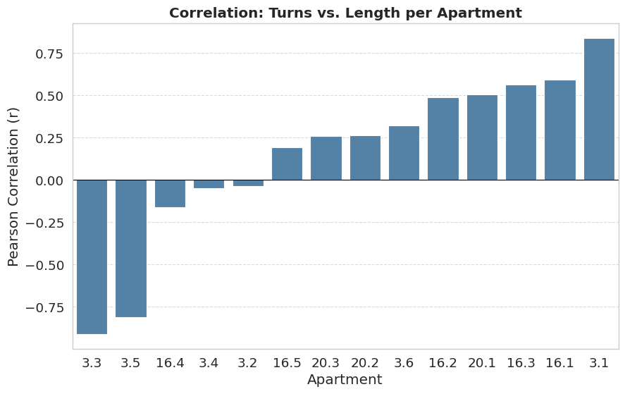

### Student Performance Consistency

Next, we calculate an 'Efficiency Score' for each student. This is the average z-score (distance from the mean) for both turns and length. A lower score means the student consistently performed better than their peers (fewer turns and shorter paths).

**Efficiency Score (Z-Score):** Standardizes performance across different apartment sizes. $$Z = \frac{x - \mu}{\sigma}$$

- A score of -1.0 means the student was 1 standard deviation better (shorter/simpler) than the class average.

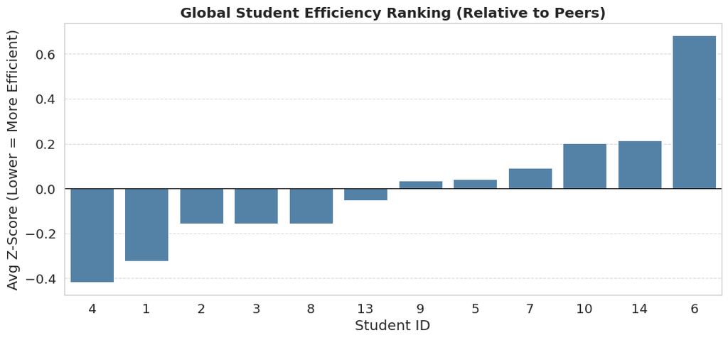

Based on standardized Z-Scores across all apartments, the following students displayed superior spatial optimization skills:

1. **Student 4 (-0.42):** Most consistent efficiency across diverse layouts.
2. **Student 1 (-0.32):** Strongest performance in the 3.x series layouts.

### Honor Roll: Most Optimized Designs

[output not shown]

## 4. Ranking & Honor Roll

The following table identifies the 'Top Performer' for each layout, defined by the lowest combined Z-Score (Efficiency Score).

| Apartment ID | Top Student | Turns | Length (10³ mm) | Efficiency Score (Z) |
| --- | --- | --- | --- | --- |
| 3.1 | 2 | 7.000000 | 19.485000 | -0.859399 |
| 3.2 | 14 | 9.000000 | 29.554900 | -1.804960 |
| 3.3 | 1 | 4.000000 | 43.535000 | -0.217705 |
| 3.4 | 1 | 8.000000 | 23.295400 | -1.145309 |
| 3.5 | 7 | 11.000000 | 28.655000 | -0.662321 |
| 3.6 | 1 | 6.000000 | 30.507400 | -0.949391 |
| 16.1 | 2 | 7.000000 | 19.485000 | -1.032099 |
| 16.2 | 4 | 7.000000 | 19.485000 | -2.070702 |
| 16.3 | 4 | 10.000000 | 29.565000 | -1.554683 |
| 16.4 | 4 | 12.000000 | 20.989800 | -1.006542 |
| 16.5 | 1 | 6.000000 | 30.507400 | -0.992713 |
| 20.1 | 2 | 7.000000 | 19.485000 | -1.002222 |
| 20.2 | 4 | 7.000000 | 19.485000 | -2.051434 |
| 20.3 | 10 | 4.000000 | 31.015000 | -1.055068 |

## 5. System Strategy: Supply vs. Exhaust

This section analyzes the **System Imbalance**, observing whether students prioritized one system's efficiency over the other due to spatial constraints.

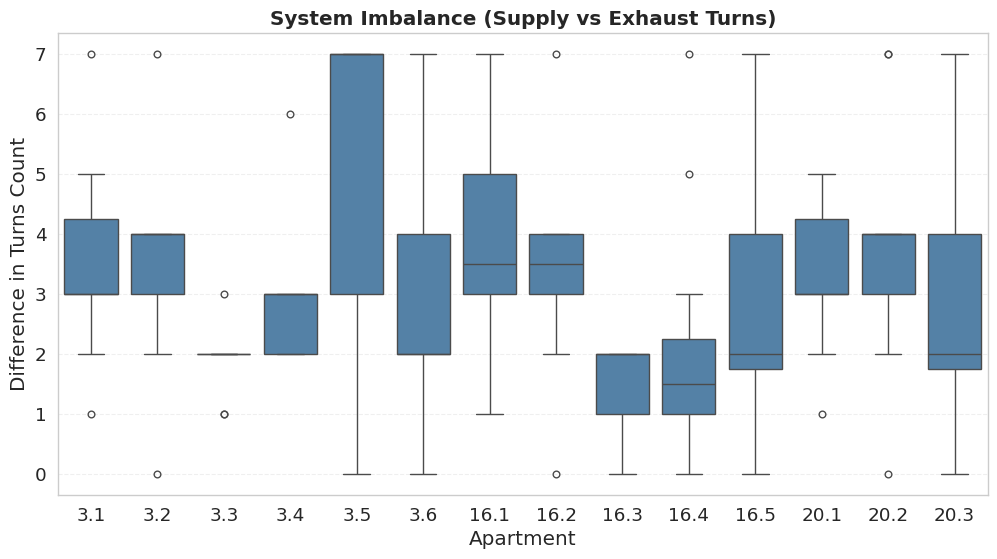

```
Insight: Higher imbalance suggests students prioritized one system's efficiency over the other due to spatial constraints.
```

| Apartment | Prioritized System | Diff |
| --- | --- | --- |
| 3.1 | Supply | 3.500000 |
| 3.2 | Supply | 3.250000 |
| 3.3 | Exhaust | 0.886364 |
| 3.4 | Supply | 2.916667 |
| 3.5 | Supply | 4.916667 |
| 3.6 | Supply | 3.083333 |
| 16.1 | Supply | 3.750000 |
| 16.2 | Supply | 3.083333 |
| 16.3 | Supply | 0.500000 |
| 16.4 | Supply | 1.333333 |
| 16.5 | Supply | 3.000000 |
| 20.1 | Supply | 3.416667 |
| 20.2 | Supply | 3.416667 |
| 20.3 | Supply | 2.500000 |

### 📉 Design Consensus vs. Divergence

Some layouts are 'solved' (everyone does the same thing), while others are 'contested' (everyone has a different idea). We measure this using the Coefficient of Variation (CV) for Path Length.

**Coefficient of Variation (CoV):** Measures 'Strategic Divergence'. $$CoV = \frac{\sigma}{\mu}$$

- High CoV: Students had very different ideas (creative puzzle).
- Low CoV: Students arrived at similar solutions (solved layout).

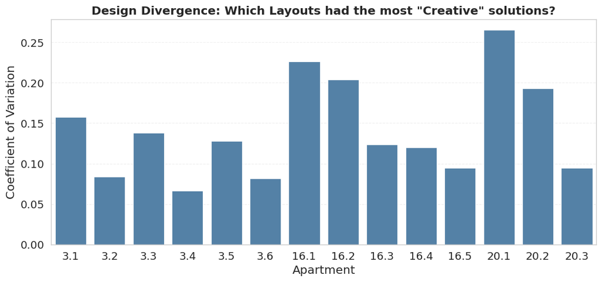

## 6. Longitudinal Analysis: The Learning Curve

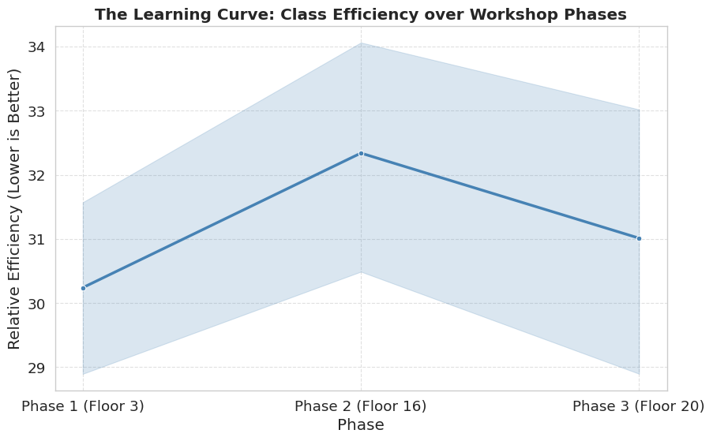

[output not shown]

## 7. Synthesis & Final Classification

We categorize the 14 layouts based on their difficulty and the diversity of student responses, mapping **Design Divergence** against **Complexity**.

### 7.1 Interpretation of the Matrix

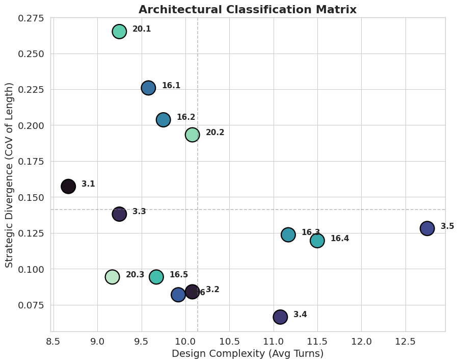